Brian Kassin **"K-State Honor Code "On my honor, as a student, I have neither given nor received unauthorized aid on this academic work.**

# What is a lexicon?

It is a collection of positive and negative words

## What lexicons are you using in this analysis?

Bing Liu Lexicon

```python
# import packages

import pandas as pd
import nltk
import csv
import re

from nltk.sentiment.vader import SentimentIntensityAnalyzer
from nltk.corpus import stopwords
from pattern.en import sentiment
from textblob import TextBlob
```

```python
# load data

openfile = open("data/hw_sentimentanalysis.csv", "r")
r = csv.reader(openfile)
reviews = []
for i in r:
    reviews.append(i[0])
openfile.close()
```

# How many movie reviews are in the dataset?

```python
# check the number of reviews in the dataset

len(reviews)
```

```
107
```

```python
# text preprocessing

# Remove useless numbers and alphanumerical words
documents = [re.sub("[^a-zA-Z]+", " ", document) for document in documents]
# tokenize
texts = [document.lower().split() for document in documents]
# remove common words
stoplist = stopwords.words('english')
texts = [[word for word in text if word not in stoplist] for text in texts]
#remove short words
texts = [[ word for word in tokens if len(word) >= 3 ] for tokens in texts]
```

```python
# Sentiment analysis using Big Liu

#Bing-Liu lexicon (positive word list & negative word list)
positive_words = open("data\\positive-words.txt", "r").read().splitlines()
negative_words = open("data\\negative-words.txt", "r").read().splitlines()

for sentence in texts:
    positive = 0
    negative = 0
    for word in sentence:
        if word in positive_words:
            positive += 1
        elif word in negative_words:
            negative += 1
    print(positive, negative, positive-negative, "Positive" if positive-negative > 0 else "Neutral" if positive-negative == 0 else "Negative")
```

```
0 0 0 Neutral
4 3 1 Positive
6 4 2 Positive
11 5 6 Positive
9 6 3 Positive
8 6 2 Positive
7 1 6 Positive
5 7 -2 Negative
7 7 0 Neutral
9 8 1 Positive
1 0 1 Positive
11 4 7 Positive
6 12 -6 Negative
10 2 8 Positive
7 4 3 Positive
```

[output cut: 92 more lines]

## How many movie reviews are positive/negative/neural according to Bing Liu’s method?

```python
positive_review = []
negative_review = []
neutral_review = []

for sentence in texts:
    positive = 0
    negative = 0
    for word in sentence:
        if word in positive_words:
            positive += 1
        elif word in negative_words:
            negative += 1
    if positive-negative > 0:
        positive_review.append(sentence)
    elif positive-negative == 0:
        neutral_review.append(sentence)
    else:
        negative_review.append(sentence)
```

```python
print(len(positive_review))
print(len(negative_review))
print(len(neutral_review))
```

```
69
28
10
```

## How many movie reviews are positive/negative/neural according to Pattern python package?

```python
# Sentiment analysis using Pattern

for row in texts:
    score = sentiment(row)
    print(score[0], score[1])
```

```
0.0 0.0
0.13111111111111112 0.49222222222222217
0.11145833333333333 0.5604166666666667
0.20491228070175438 0.5332456140350876
0.1401315789473684 0.4657894736842104
0.1378787878787879 0.3878787878787879
0.2234375 0.4510416666666667
0.03295454545454546 0.45454545454545453
0.006666666666666659 0.38333333333333325
0.10297280844155846 0.6294642857142856
0.9 1.0
0.1603896103896104 0.5739177489177489
-0.19242424242424241 0.6416666666666667
0.560763888888889 0.7135416666666666
0.36319444444444443 0.5854166666666667
0.13511463844797175 0.41582010582010587
-0.0031250000000000028 0.521875
-0.003508771929824555 0.5679197994987468
0.14666666666666667 0.45
-0.22687500000000002 0.47104166666666664
0.35 0.5984848484848485
0.2520833333333333 0.5
0.24895833333333336 0.5874999999999999
0.3484848484848485 0.503030303030303
-0.11666666666666668 0.48333333333333334
0.2924242424242424 0.5
0.019907407407407398 0.5219907407407407
-0.09682539682539683 0.4595238095238095
0.2550595238095238 0.61875
-0.21282051282051279 0.4371794871794872
0.40173469387755106 0.6898469387755101
0.30238095238095236 0.40654761904761905
0.18148148148148147 0.4962962962962964
-0.004068627450980383 0.5781699346405229
0.5222222222222223 0.588888888888889
0.49328571428571427 0.7328571428571429
0.2960714285714286 0.44523809523809527
-0.09055555555555554 0.5044444444444445
0.07243589743589743 0.4955128205128205
0.26875000000000004 0.6250000000000001
```

[output cut: 52 more lines]

```
0.24204545454545454 0.5130681818181818
0.9 0.525
-0.07055785123966941 0.4958677685950413
-0.06492673992673992 0.610989010989011
0.16136363636363635 0.537878787878788
0.09333333333333335 0.2833333333333333
0.04285714285714285 0.42857142857142855
0.2928571428571428 0.5261904761904762
0.3428571428571429 0.5285714285714286
-0.2781060606060606 0.5137121212121212
0.2909090909090909 0.502922077922078
0.26285714285714284 0.6742857142857143
0.26999999999999996 0.66
0.21886446886446886 0.719047619047619
0.11009469696969698 0.5421212121212121
```

```python
positive_review1 = []
negative_review1 = []
neutral_review1 = []

for row in reviews:
    score = sentiment(row)
    if score[0] > 0:
        positive_review1.append(row)
    elif score[0] == 0:
        neutral_review1.append(row)
    else:
        negative_review1.append(row)
```

```python
print(len(positive_review1))
print(len(negative_review1))
print(len(neutral_review1))
```

```
81
25
1
```

## How many movie reviews are positive/negative/neural according to Textblob python package?

```python
for row in reviews:
    print(TextBlob(row).sentiment.polarity, TextBlob(row).sentiment.subjectivity)
```

```
0.0 0.0
0.14841269841269839 0.5015873015873016
0.06385964912280702 0.5629824561403508
0.21966666666666662 0.5315833333333333
0.19282894736842107 0.4563157894736841
0.16805555555555554 0.3972222222222222
0.23970588235294119 0.453921568627451
0.07187500000000001 0.4583333333333333
-0.056666666666666664 0.38333333333333325
0.10264249639249637 0.6039682539682539
0.9 1.0
0.23316326530612244 0.558078231292517
-0.1894927536231884 0.630072463768116
0.5337820512820513 0.7494230769230769
0.28802083333333334 0.57625
0.1280033416875522 0.4465664160401003
-0.0031250000000000028 0.521875
-0.01008771929824561 0.5797619047619047
0.13958333333333334 0.4625
-0.15380434782608696 0.4965579710144928
0.3153846153846154 0.6602564102564101
0.21607142857142855 0.5714285714285714
0.18166666666666667 0.6035294117647059
0.37179487179487186 0.5025641025641026
-0.05694444444444444 0.5263888888888889
0.3074404761904762 0.46428571428571436
0.0691468253968254 0.5259920634920634
-0.1268253968253968 0.4623015873015873
0.3073968253968254 0.664
-0.25243589743589745 0.4694871794871795
0.3728571428571429 0.6506302521008402
0.30238095238095236 0.40654761904761905
0.21944444444444444 0.4659722222222223
0.05402777777777778 0.6108641975308643
0.5750000000000001 0.6125
0.49328571428571427 0.7328571428571429
0.32896825396825397 0.48359788359788364
-0.025490196078431372 0.503921568627451
0.12135416666666665 0.5276041666666667
0.315 0.6000000000000001
```

[output cut: 52 more lines]

```
0.3269421487603306 0.5604132231404958
0.6666666666666666 0.45
-0.06208513708513709 0.5638167388167388
-0.05338827838827838 0.610989010989011
0.16136363636363635 0.537878787878788
0.09333333333333335 0.2833333333333333
-0.04166666666666667 0.4083333333333333
0.23125 0.4729166666666667
0.23953993055555559 0.5638888888888889
-0.09881628787878788 0.42888257575757577
0.30833333333333335 0.5026785714285714
0.21904761904761905 0.4994047619047619
0.059999999999999984 0.66
0.24637445887445886 0.5942099567099567
0.10622113997113997 0.5498773448773449
```

```python
positive_review2 = []
negative_review2 = []
neutral_review2 = []

for row in reviews:
    score = TextBlob(row).sentiment.polarity
    if score > 0:
        positive_review2.append(row)
    elif score == 0:
        neutral_review2.append(row)
    else:
        negative_review2.append(row)
```

```python
print(len(positive_review2))
print(len(negative_review2))
print(len(neutral_review2))
```

```
81
25
1
```

## How many movie reviews are positive/negative/neural according to vaderSentiment python package?

```python
analyzer = SentimentIntensityAnalyzer()

for row in reviews:
    vs = analyzer.polarity_scores(row)
    print(vs["compound"])
```

```
0.0
0.7956
-0.5349
0.9818
0.9684
0.6739
0.9707
-0.0027
0.4113
0.9575
0.5859
0.9765
-0.9892
0.9943
0.9864
0.7204
-0.8173
0.128
0.34
-0.8628
0.9828
0.4678
0.0134
0.9754
-0.7107
0.9558
0.9249
-0.7005
0.9532
-0.9939
0.99
0.967
0.9756
0.6471
0.9343
0.9964
0.9268
-0.9689
0.099
0.6249
```

[output cut: 52 more lines]

```
0.9846
0.5984
0.8851
0.3628
0.9425
0.9723
0.6941
0.8558
0.9588
-0.114
0.9612
0.5994
-0.6377
0.9907
0.7058
```

```python
positive_review3 = []
negative_review3 = []
neutral_review3 = []

for row in reviews:
    vs = analyzer.polarity_scores(row)
    score = vs["compound"]
    if score > 0:
        positive_review3.append(row)
    elif score == 0:
        neutral_review3.append(row)
    else:
        negative_review3.append(row)
```

```python
print(len(positive_review3))
print(len(negative_review3))
print(len(neutral_review3))
```

```
85
21
1
```

# Which method seems to be working better for this movie dataset? Explain why?

I think that the vaderSentiment seems to be working the best for this data as it holds the most information and insight about the data because the vaderSentiment package was developed for rating reviews

# Overall, how would you describe the viewer’s feelings around the movies? If the data are the reviews of a particular movie, how would you predict the success of the movie?

Overall, I believe that the viewers have a positive feeling around the movies and if this data was about a specific movie then I would think that this specific movie should be fairly successfull

# positive review word frequency and word cloud

```python
# load data

openfile = open("data/hw_sentimentanalysis.csv", "r")
r = csv.reader(openfile)
reviews = []
for i in r:
    reviews.append(i[0])
openfile.close()
```

```python
analyzer = SentimentIntensityAnalyzer()

for row in reviews:
    vs = analyzer.polarity_scores(row)
    print(vs["compound"])
```

```
0.0
0.7956
-0.5349
0.9818
0.9684
0.6739
0.9707
-0.0027
0.4113
0.9575
0.5859
0.9765
-0.9892
0.9943
0.9864
0.7204
-0.8173
0.128
0.34
-0.8628
0.9828
0.4678
0.0134
0.9754
-0.7107
0.9558
0.9249
-0.7005
0.9532
-0.9939
0.99
0.967
0.9756
0.6471
0.9343
0.9964
0.9268
-0.9689
0.099
0.6249
```

[output cut: 52 more lines]

```
0.9846
0.5984
0.8851
0.3628
0.9425
0.9723
0.6941
0.8558
0.9588
-0.114
0.9612
0.5994
-0.6377
0.9907
0.7058
```

```python
positive_review3 = []
negative_review3 = []
neutral_review3 = []

for row in reviews:
    vs = analyzer.polarity_scores(row)
    score = vs["compound"]
    if score > 0:
        positive_review3.append(row)
    elif score == 0:
        neutral_review3.append(row)
    else:
        negative_review3.append(row)
```

```python
print(len(positive_review3))
print(len(negative_review3))
print(len(neutral_review3))
```

```
85
21
1
```

```python
# Remove useless numbers and alphanumerical words
documents = [re.sub("[^a-zA-Z]+", " ", document) for document in positive_review3]
# tokenize
texts = [document.lower().split() for document in documents]
# remove common words
stoplist = stopwords.words('english')
texts = [[word for word in text if word not in stoplist] for text in texts]
# if you want to remove additional words
more = set(['text', 'movie', 'movies', 'film', 'films', 'see', 'look'])
stoplist = set(stoplist) | more
#remove short words
texts = [[ word for word in tokens if len(word) >= 3 ] for tokens in texts]
```

```python
# remove extra brackets)
cleaned_positive_review_tokens = [x for y in texts for x in y]
cleaned_positive_review_tokens[:10]
```

```
['went',
 'saw',
 'movie',
 'last',
 'night',
 'coaxed',
 'friends',
 'mine',
 'admit',
 'reluctant']
```

```python
# word frequency
from collections import Counter

positive_review_wordcounts= Counter(cleaned_positive_review_tokens)
positive_review_wordcounts.most_common(10)
```

```
[('movie', 109),
 ('film', 92),
 ('great', 46),
 ('one', 45),
 ('see', 36),
 ('like', 33),
 ('story', 33),
 ('good', 30),
 ('would', 30),
 ('well', 28)]
```

Popular words in positive review = film, great, one, see, etc.

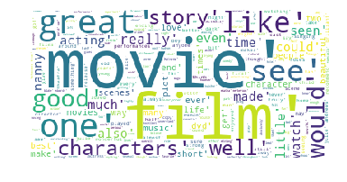

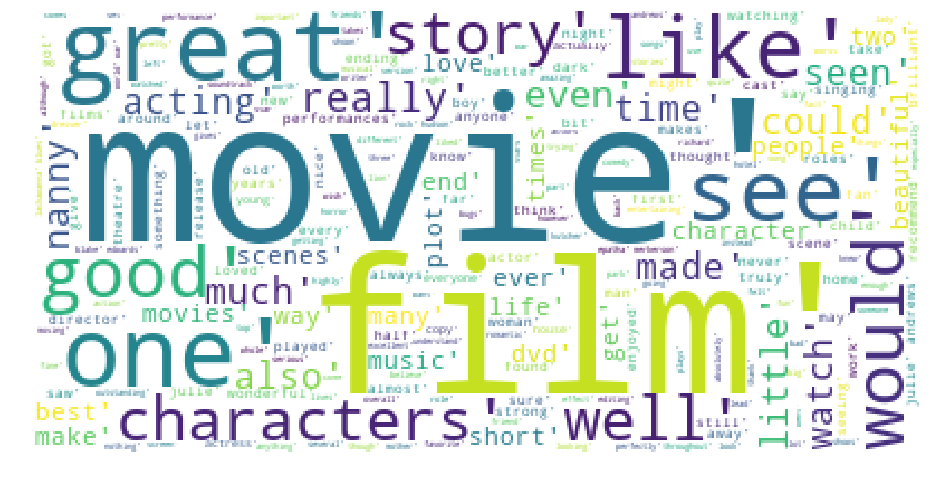

```python
# This process could be very slow for a large corpus

from os import path
from wordcloud import WordCloud, STOPWORDS
import matplotlib.pyplot as plt
%matplotlib inline

text = str(cleaned_positive_review_tokens)

# Generate a word cloud image
wc = WordCloud(background_color="white", max_words=2000).generate(text)
wc.generate(text)

# Display the generated image:
# the matplotlib way:
plt.imshow(wc)
plt.axis("off")

# take relative word frequencies into account, lower max_font_size
#wordcloud = WordCloud(max_font_size=40, relative_scaling=.5).generate(text)
plt.figure(figsize=(16,16))
plt.imshow(wc)
plt.axis("off")
plt.savefig("data/pos.png")
plt.savefig("data/pos.pdf")
```